# Analysis of samples responses from solvers

In this notebook, it is written the analysis of samples from solvers (SA and QPU) in the standard experiment of **{loss: NORM_MSE; aggregation: FIRST; top_k: 5}**

```python
import os, sys
import numpy as np
import matplotlib.pyplot as plt
import pandas as pd

sys.path.append("../")
```

```python
from src.utils.utilities import get_project_root_path
```

```python
sa_folder = os.path.join(get_project_root_path(), "report", "quantum_slim", "Aug28_11-12-58")
qpu_folder = os.path.join(get_project_root_path(), "report", "quantum_slim", "Aug28_11-52-32")
```

## Simulated annealing energy analysis

```python
sa_df = pd.read_csv(os.path.join(sa_folder, "solver_responses.csv"))
```

```python
sa_df.head()
```

|  | a00 | a01 | a02 | a03 | a04 | a05 | a06 | a07 | a08 | a09 | ... | a43 | a44 | a45 | a46 | a47 | a48 | a49 | energy | item_id | num_occurrences |
| --- | --- | --- | --- | --- | --- | --- | --- | --- | --- | --- | --- | --- | --- | --- | --- | --- | --- | --- | --- | --- | --- |
| 0 | 0.0 | 1.0 | 0.0 | 0.0 | 0.0 | 0.0 | 0.0 | 0.0 | 0.0 | 0.0 | ... | 0.0 | 0.0 | 0.0 | 0.0 | 0.0 | 1.0 | 0.0 | -24465.0 | 0 | 1 |
| 1 | 0.0 | 0.0 | 0.0 | 0.0 | 0.0 | 0.0 | 0.0 | 0.0 | 0.0 | 0.0 | ... | 1.0 | 0.0 | 0.0 | 0.0 | 0.0 | 0.0 | 0.0 | -24821.0 | 0 | 1 |
| 2 | 0.0 | 0.0 | 0.0 | 0.0 | 0.0 | 0.0 | 0.0 | 0.0 | 0.0 | 0.0 | ... | 0.0 | 0.0 | 0.0 | 0.0 | 0.0 | 0.0 | 0.0 | -24205.0 | 0 | 1 |
| 3 | 0.0 | 0.0 | 1.0 | 0.0 | 0.0 | 0.0 | 1.0 | 0.0 | 0.0 | 0.0 | ... | 0.0 | 0.0 | 0.0 | 0.0 | 0.0 | 0.0 | 0.0 | -24696.0 | 0 | 1 |
| 4 | 0.0 | 0.0 | 0.0 | 0.0 | 0.0 | 0.0 | 0.0 | 1.0 | 0.0 | 0.0 | ... | 0.0 | 0.0 | 0.0 | 1.0 | 0.0 | 0.0 | 0.0 | -24086.0 | 0 | 1 |

5 rows × 53 columns

Let's first analyze the energy on all items. For this, we will do multiple min-max normalization on the energy for each item id.

```python
for curr_item in sa_df["item_id"].unique():
    max_value = sa_df.loc[sa_df.item_id == curr_item, "energy"].max()
    min_value = sa_df.loc[sa_df.item_id == curr_item, "energy"].min()
    sa_df.loc[sa_df.item_id == curr_item, "energy"] = (sa_df.loc[sa_df.item_id == curr_item, "energy"] - min_value)/(max_value - min_value)
```

```python
sa_df.head()
```

|  | a00 | a01 | a02 | a03 | a04 | a05 | a06 | a07 | a08 | a09 | ... | a43 | a44 | a45 | a46 | a47 | a48 | a49 | energy | item_id | num_occurrences |
| --- | --- | --- | --- | --- | --- | --- | --- | --- | --- | --- | --- | --- | --- | --- | --- | --- | --- | --- | --- | --- | --- |
| 0 | 0.0 | 1.0 | 0.0 | 0.0 | 0.0 | 0.0 | 0.0 | 0.0 | 0.0 | 0.0 | ... | 0.0 | 0.0 | 0.0 | 0.0 | 0.0 | 1.0 | 0.0 | 0.323157 | 0 | 1 |
| 1 | 0.0 | 0.0 | 0.0 | 0.0 | 0.0 | 0.0 | 0.0 | 0.0 | 0.0 | 0.0 | ... | 1.0 | 0.0 | 0.0 | 0.0 | 0.0 | 0.0 | 0.0 | 0.118088 | 0 | 1 |
| 2 | 0.0 | 0.0 | 0.0 | 0.0 | 0.0 | 0.0 | 0.0 | 0.0 | 0.0 | 0.0 | ... | 0.0 | 0.0 | 0.0 | 0.0 | 0.0 | 0.0 | 0.0 | 0.472926 | 0 | 1 |
| 3 | 0.0 | 0.0 | 1.0 | 0.0 | 0.0 | 0.0 | 1.0 | 0.0 | 0.0 | 0.0 | ... | 0.0 | 0.0 | 0.0 | 0.0 | 0.0 | 0.0 | 0.0 | 0.190092 | 0 | 1 |
| 4 | 0.0 | 0.0 | 0.0 | 0.0 | 0.0 | 0.0 | 0.0 | 1.0 | 0.0 | 0.0 | ... | 0.0 | 0.0 | 0.0 | 1.0 | 0.0 | 0.0 | 0.0 | 0.541475 | 0 | 1 |

5 rows × 53 columns

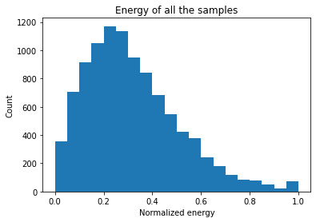

```python
plt.hist(sa_df["energy"], bins=20)
plt.title("Energy of all the samples")
plt.ylabel("Count")
plt.xlabel("Normalized energy")
plt.show()
```

We know that the lower the energy the lower is the loss. If we consider that SA actually find the lowest sample, then this happens quite a few time. Instead, most of the sample falls on a normalized energy of 0.2.

This plot does not imply anything at all. But now, let's see if every item has this behavior or not.

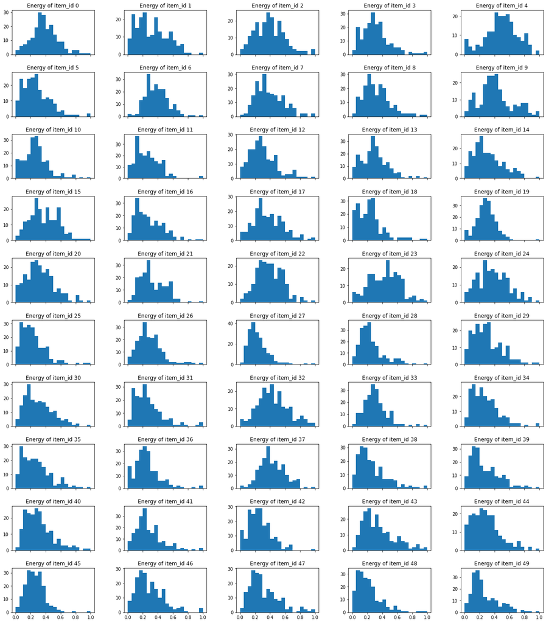

```python
fig, axes = plt.subplots(10, 5, figsize=(18, 20), sharex=True)
fig.tight_layout(pad=3.0)

for curr_item in sa_df["item_id"].unique():
    curr_samples = sa_df[sa_df["item_id"] == curr_item]

    col_idx = curr_item % 5
    row_idx = curr_item // 5
    axes[row_idx, col_idx].hist(curr_samples["energy"], bins=20)
    axes[row_idx, col_idx].set_title("Energy of item_id {}".format(curr_item))
plt.show()
```

Looking at the shapes, there are some in which the very lowest energy sample happens more times or cases in which the worst sample among all of them happens more often. We could investigate on them, but let's first analyze the QPU solver.

## QPU energy analysis

```python
qpu_df = pd.read_csv(os.path.join(qpu_folder, "solver_responses.csv"))
```

```python
qpu_df.head()
```

|  | a00 | a01 | a02 | a03 | a04 | a05 | a06 | a07 | a08 | a09 | ... | a44 | a45 | a46 | a47 | a48 | a49 | chain_break_fraction | energy | item_id | num_occurrences |
| --- | --- | --- | --- | --- | --- | --- | --- | --- | --- | --- | --- | --- | --- | --- | --- | --- | --- | --- | --- | --- | --- |
| 0 | 0.0 | 0.0 | 0.0 | 0.0 | 0.0 | 0.0 | 0.0 | 0.0 | 0.0 | 0.0 | ... | 0.0 | 0.0 | 1.0 | 0.0 | 0.0 | 0.0 | 0.000000 | -15417.0 | 0 | 1 |
| 1 | 0.0 | 0.0 | 0.0 | 0.0 | 0.0 | 0.0 | 0.0 | 0.0 | 0.0 | 0.0 | ... | 0.0 | 0.0 | 0.0 | 0.0 | 0.0 | 0.0 | 0.020408 | -8015.0 | 0 | 1 |
| 2 | 0.0 | 0.0 | 0.0 | 0.0 | 1.0 | 0.0 | 0.0 | 0.0 | 0.0 | 1.0 | ... | 0.0 | 0.0 | 0.0 | 0.0 | 0.0 | 0.0 | 0.040816 | 4252.0 | 0 | 1 |
| 3 | 0.0 | 0.0 | 0.0 | 0.0 | 1.0 | 0.0 | 0.0 | 0.0 | 0.0 | 1.0 | ... | 0.0 | 0.0 | 0.0 | 0.0 | 0.0 | 0.0 | 0.040816 | -6832.0 | 0 | 1 |
| 4 | 0.0 | 0.0 | 0.0 | 0.0 | 0.0 | 0.0 | 0.0 | 0.0 | 0.0 | 0.0 | ... | 1.0 | 0.0 | 0.0 | 0.0 | 0.0 | 0.0 | 0.061224 | -16272.0 | 0 | 1 |

5 rows × 54 columns

In the QPU, we have also the column of chain_break_fraction that indicates the percentage of chains of qubits (that are necessary during the embedding due to the infrastructure of the quantum machine) that has been broken. First, let's look at the energy and compare it with the simulated annealing case.

```python
for curr_item in qpu_df["item_id"].unique():
    max_value = qpu_df.loc[qpu_df.item_id == curr_item, "energy"].max()
    min_value = qpu_df.loc[qpu_df.item_id == curr_item, "energy"].min()
    qpu_df.loc[qpu_df.item_id == curr_item, "energy"] = (qpu_df.loc[qpu_df.item_id == curr_item, "energy"] - min_value)/(max_value - min_value)
```

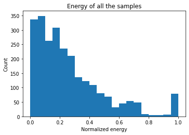

```python
plt.hist(qpu_df["energy"], bins=20)
plt.title("Energy of all the samples")
plt.ylabel("Count")
plt.xlabel("Normalized energy")
plt.show()
```

Looking at the global energy, the QPU energies are more concentrated on the lowest energy, but we do not know if the lowest energy of the samples of QPU is actually the lowest. Maybe we can see something if we compare it with the SA case. But first let's see all the 50 items independently.

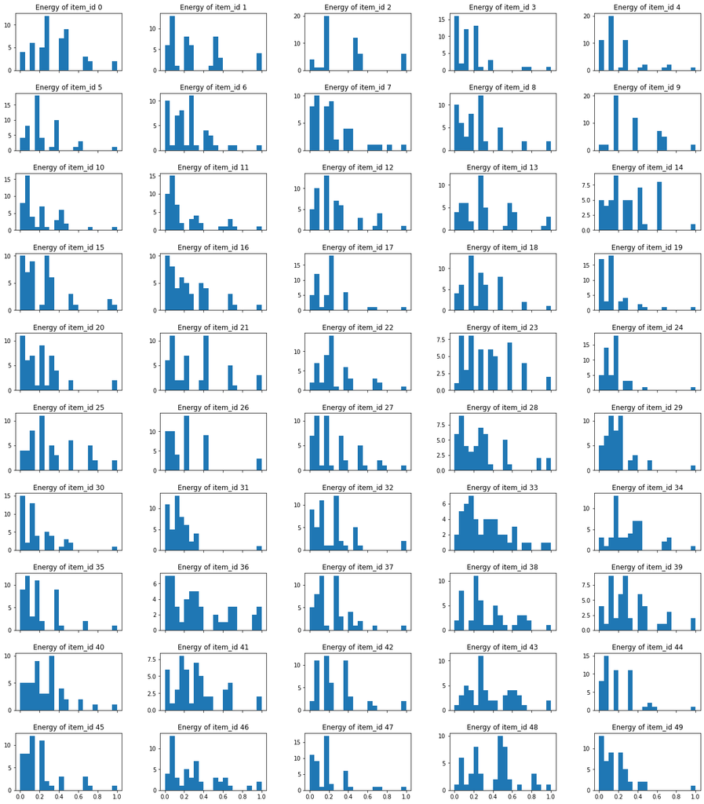

```python
fig, axes = plt.subplots(10, 5, figsize=(18, 20), sharex=True)
fig.tight_layout(pad=3.0)

for curr_item in qpu_df["item_id"].unique():
    curr_samples = qpu_df[qpu_df["item_id"] == curr_item]

    col_idx = curr_item % 5
    row_idx = curr_item // 5
    axes[row_idx, col_idx].hist(curr_samples["energy"], bins=20)
    axes[row_idx, col_idx].set_title("Energy of item_id {}".format(curr_item))
plt.show()
```

Due to the smaller number of samples (50 of QPU against 200 of SA), the histograms are not so good. Also in this case there are some different behavior in the items.

## Energy comparison analysis between QPU and SA

```python
qpu_df = pd.read_csv(os.path.join(qpu_folder, "solver_responses.csv"))
sa_df = pd.read_csv(os.path.join(sa_folder, "solver_responses.csv"))
```

In this case, the global energy can be seen with multiple min-max normalization using the min and max among both QPU and SA.

```python
for curr_item in qpu_df["item_id"].unique():
    qpu_max_value = qpu_df.loc[qpu_df.item_id == curr_item, "energy"].max()
    qpu_min_value = qpu_df.loc[qpu_df.item_id == curr_item, "energy"].min()

    sa_max_value = sa_df.loc[sa_df.item_id == curr_item, "energy"].max()
    sa_min_value = sa_df.loc[sa_df.item_id == curr_item, "energy"].min()

    max_value = max(qpu_max_value, sa_max_value)
    min_value = min(qpu_min_value, sa_min_value)

    qpu_df.loc[qpu_df.item_id == curr_item, "energy"] = (qpu_df.loc[qpu_df.item_id == curr_item, "energy"] - min_value)/(max_value - min_value)
    sa_df.loc[sa_df.item_id == curr_item, "energy"] = (sa_df.loc[sa_df.item_id == curr_item, "energy"] - min_value)/(max_value - min_value)
```

```python
qpu_df.head()
```

|  | a00 | a01 | a02 | a03 | a04 | a05 | a06 | a07 | a08 | a09 | ... | a44 | a45 | a46 | a47 | a48 | a49 | chain_break_fraction | energy | item_id | num_occurrences |
| --- | --- | --- | --- | --- | --- | --- | --- | --- | --- | --- | --- | --- | --- | --- | --- | --- | --- | --- | --- | --- | --- |
| 0 | 0.0 | 0.0 | 0.0 | 0.0 | 0.0 | 0.0 | 0.0 | 0.0 | 0.0 | 0.0 | ... | 0.0 | 0.0 | 1.0 | 0.0 | 0.0 | 0.0 | 0.000000 | 0.151823 | 0 | 1 |
| 1 | 0.0 | 0.0 | 0.0 | 0.0 | 0.0 | 0.0 | 0.0 | 0.0 | 0.0 | 0.0 | ... | 0.0 | 0.0 | 0.0 | 0.0 | 0.0 | 0.0 | 0.020408 | 0.268774 | 0 | 1 |
| 2 | 0.0 | 0.0 | 0.0 | 0.0 | 1.0 | 0.0 | 0.0 | 0.0 | 0.0 | 1.0 | ... | 0.0 | 0.0 | 0.0 | 0.0 | 0.0 | 0.0 | 0.040816 | 0.462593 | 0 | 1 |
| 3 | 0.0 | 0.0 | 0.0 | 0.0 | 1.0 | 0.0 | 0.0 | 0.0 | 0.0 | 1.0 | ... | 0.0 | 0.0 | 0.0 | 0.0 | 0.0 | 0.0 | 0.040816 | 0.287466 | 0 | 1 |
| 4 | 0.0 | 0.0 | 0.0 | 0.0 | 0.0 | 0.0 | 0.0 | 0.0 | 0.0 | 0.0 | ... | 1.0 | 0.0 | 0.0 | 0.0 | 0.0 | 0.0 | 0.061224 | 0.138314 | 0 | 1 |

5 rows × 54 columns

```python
sa_df.head()
```

|  | a00 | a01 | a02 | a03 | a04 | a05 | a06 | a07 | a08 | a09 | ... | a43 | a44 | a45 | a46 | a47 | a48 | a49 | energy | item_id | num_occurrences |
| --- | --- | --- | --- | --- | --- | --- | --- | --- | --- | --- | --- | --- | --- | --- | --- | --- | --- | --- | --- | --- | --- |
| 0 | 0.0 | 1.0 | 0.0 | 0.0 | 0.0 | 0.0 | 0.0 | 0.0 | 0.0 | 0.0 | ... | 0.0 | 0.0 | 0.0 | 0.0 | 0.0 | 1.0 | 0.0 | 0.008864 | 0 | 1 |
| 1 | 0.0 | 0.0 | 0.0 | 0.0 | 0.0 | 0.0 | 0.0 | 0.0 | 0.0 | 0.0 | ... | 1.0 | 0.0 | 0.0 | 0.0 | 0.0 | 0.0 | 0.0 | 0.003239 | 0 | 1 |
| 2 | 0.0 | 0.0 | 0.0 | 0.0 | 0.0 | 0.0 | 0.0 | 0.0 | 0.0 | 0.0 | ... | 0.0 | 0.0 | 0.0 | 0.0 | 0.0 | 0.0 | 0.0 | 0.012972 | 0 | 1 |
| 3 | 0.0 | 0.0 | 1.0 | 0.0 | 0.0 | 0.0 | 1.0 | 0.0 | 0.0 | 0.0 | ... | 0.0 | 0.0 | 0.0 | 0.0 | 0.0 | 0.0 | 0.0 | 0.005214 | 0 | 1 |
| 4 | 0.0 | 0.0 | 0.0 | 0.0 | 0.0 | 0.0 | 0.0 | 1.0 | 0.0 | 0.0 | ... | 0.0 | 0.0 | 0.0 | 1.0 | 0.0 | 0.0 | 0.0 | 0.014852 | 0 | 1 |

5 rows × 53 columns

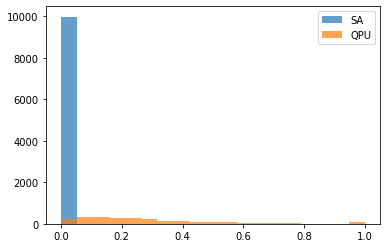

```python
bins = np.linspace(0, 1, 20)
plt.hist(sa_df["energy"], bins=bins, alpha=0.7, label="SA")
plt.hist(qpu_df["energy"], bins=bins, alpha=0.7, label="QPU")
plt.legend()
plt.show()
```

Interestingly, we can see that SA samples are all on the lowest level of energy, while QPU samples are scattered across the range of values. This shows that QPU samples are quite bad; maybe it is due to the chain break fraction.

Also, we can see samples of QPU extremely high (i.e. near 1.0). Maybe, these are due to the read errors of quantum machine.

But now, let's compare each individual item.

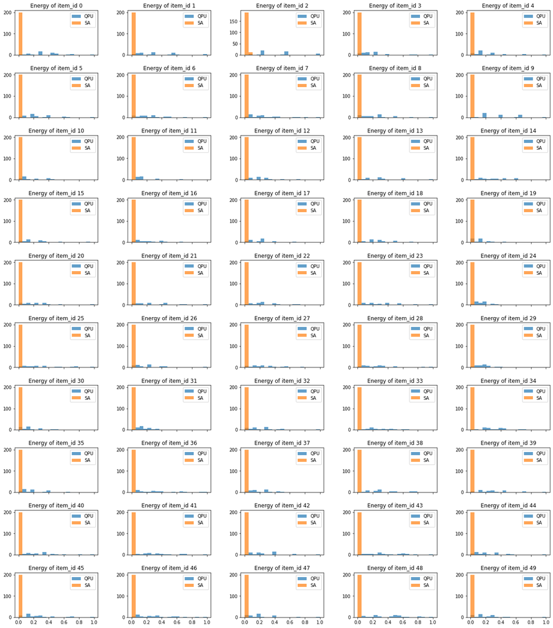

```python
fig, axes = plt.subplots(10, 5, figsize=(18, 20), sharex=True)
fig.tight_layout(pad=3.0)
bins = np.linspace(0, 1, 20)

for curr_item in qpu_df["item_id"].unique():
    qpu_curr_samples = qpu_df[qpu_df["item_id"] == curr_item]
    sa_curr_samples = sa_df[sa_df["item_id"] == curr_item]

    col_idx = curr_item % 5
    row_idx = curr_item // 5
    axes[row_idx, col_idx].hist(qpu_curr_samples["energy"], bins=bins, alpha=0.7, label="QPU")
    axes[row_idx, col_idx].hist(sa_curr_samples["energy"], bins=bins, alpha=0.7, label="SA")
    axes[row_idx, col_idx].legend()
    axes[row_idx, col_idx].set_title("Energy of item_id {}".format(curr_item))
plt.show()
```

Looking at these plots, we can see that SA is almost always on the first bin while sometimes QPU samples seems to never be in the first bin.

## QPU chain break fraction analysis

```python
qpu_df = pd.read_csv(os.path.join(qpu_folder, "solver_responses.csv"))
```

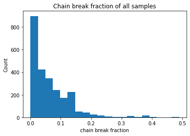

```python
plt.hist(qpu_df["chain_break_fraction"], bins=20)
plt.title("Chain break fraction of all samples")
plt.xlabel("chain break fraction")
plt.ylabel("Count")
plt.show()
```

Looking at these chain break fraction, there are quite a lot of samples with a fraction greater than 0.1.

Now, let's see for each different item, if there is a difference in this distribution of chain break fraction.

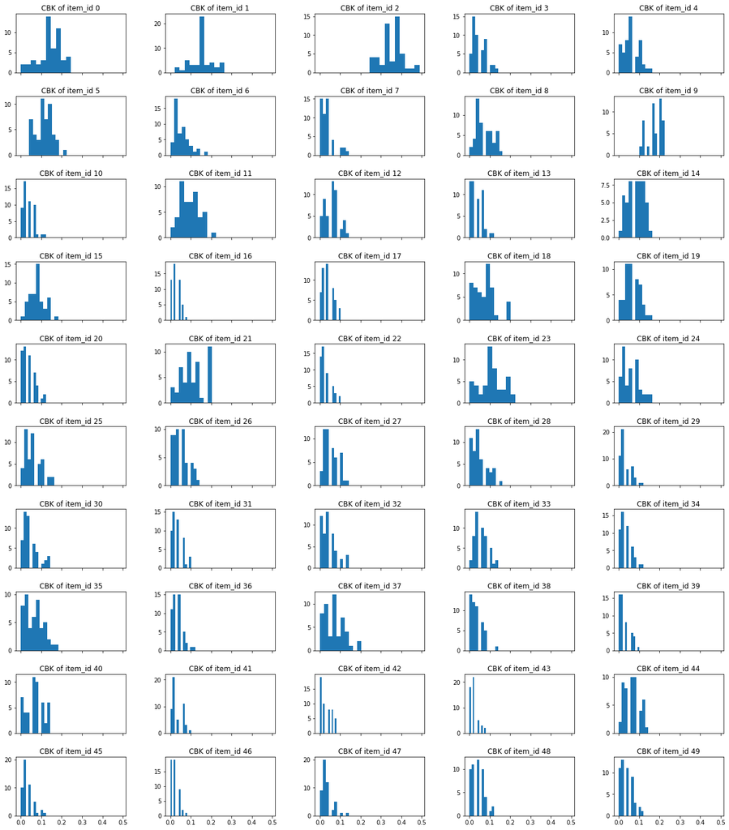

```python
fig, axes = plt.subplots(10, 5, figsize=(18, 20), sharex=True)
fig.tight_layout(pad=3.0)
bins = np.linspace(0, 0.5, 20)

for curr_item in qpu_df["item_id"].unique():
    curr_samples = qpu_df[qpu_df["item_id"] == curr_item]

    col_idx = curr_item % 5
    row_idx = curr_item // 5
    axes[row_idx, col_idx].hist(curr_samples["chain_break_fraction"])
    axes[row_idx, col_idx].set_title("CBK of item_id {}".format(curr_item))
plt.show()
```

As we can see with a share x-axis, there are some that has almost all high chain break fraction samples (e.g. item_id=2), while most of the others has samples with chain break fraction lower than 0.1.

Maybe we can try to look into the type of item. For example, the popularity, the type of ratings, the total sum of ratings and so on... Or maybe we can increase the strength of the chain when doing the embedding in order to obtain samples with lower chain break fraction.